# Health and Economic Outcomes of Weather Events 1951-2011: An Overview

## Analysis

### Part 1: Public Health Outcomes

Question is: Across the United States, which types of events (as indicated in the **EVTYPE** variable) are most harmful with respect to population health?

We have created an *outcomes* table before. We will create a barplot to show the health outcomes. *ggplot2* package will be used.

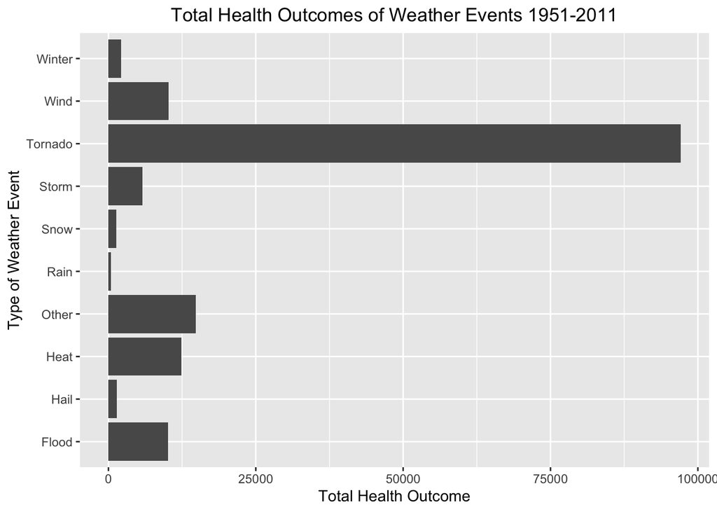

```r
library(ggplot2)
plot1  <- ggplot(data = outcomes, aes(x=totalHealth, y=EVENT), ) +
     geom_bar(stat="identity") +
     xlab("Total Health Outcome") +
     ylab("Type of Weather Event") +
     ggtitle("Total Health Outcomes of Weather Events 1951-2011") +
     theme(plot.title = element_text(hjust = 0.5))

plot1
```

As a result, worst health outcomes had been seen because of tornados.

### Part 2: Economic outcomes

Question is: Across the United States, which types of events have the greatest economic consequences?

*outcomes* dataset will be used.

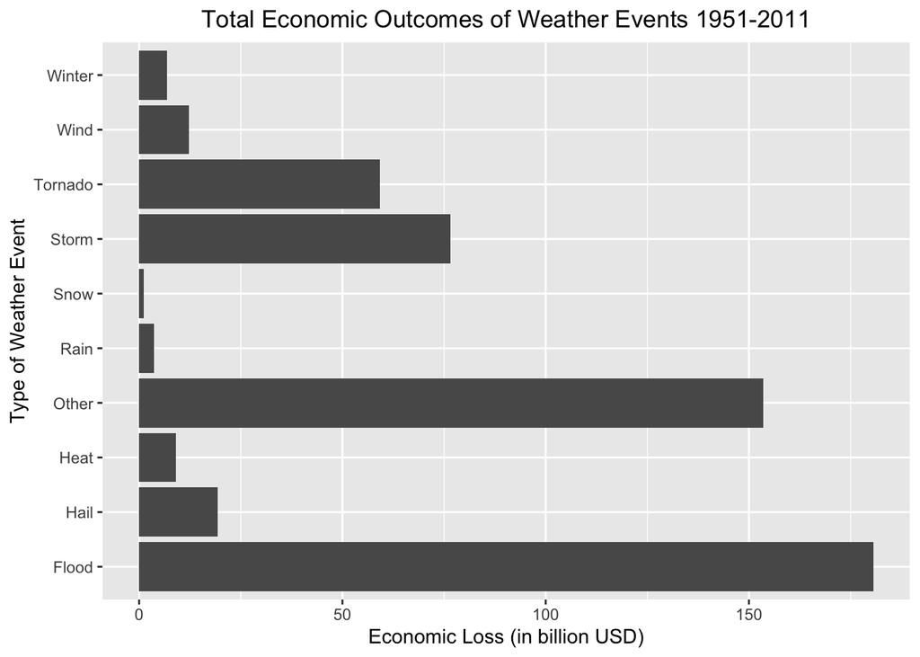

```r
plot2 <- ggplot(data= outcomes, aes(x= totalEcon/1E9, y= EVENT)) +
     geom_histogram(stat = "identity") +
     xlab("Economic Loss (in billion USD)") +
     ylab("Type of Weather Event") +
     ggtitle("Total Economic Outcomes of Weather Events 1951-2011") +
     theme(plot.title = element_text(hjust = 0.5))

plot2
```

As a result, we can say that most devastating event for property and corps is flood. (excluding “others”)